# The hyperparameter choice - pt. 2

In this notebook we will visualize the effect of the choice of elastic tree hyperparameters for the elastic and embedded tree. In the second part we will be working with the dataset by Paul *et al.*, detailing mouse hematopoiesis. We will be needing MERLoT, Monocle 2, as well as some customized versions of the MERLoT functions.

```r
library(merlot)
library(monocle)
source("~/Documents/repos/merlot-scripts/scripts/niko_tree_funcs.R")
```

We will read the dataset and the annotation.

```r
CellTypes= paste(find.package("merlot"), "/example/PaulCellsMapping.csv", sep="")
Types=read.table(file =CellTypes, header=F, stringsAsFactors = F, sep=",")
paul_colorcells=c()
selected_colors=c("cyan1", "cyan4", "darkcyan",  "blue", "darkblue", "blue4", "navy", "darkgoldenrod", "darkgoldenrod1", "darkgoldenrod1", "gold", "bisque", "palegreen", "darkolivegreen2", "darkolivegreen3", "darkolivegreen4", "darkolivegreen", "chartreuse4", "darkgreen")
for(i in 1:19)
{
  paul_colorcells[which(Types[,2]==i)]=selected_colors[i]
}

ExpressionData=paste(find.package("merlot"), "/example/Paul2015.txt", sep="")
raw <- read.table(ExpressionData, sep="\t", header=T, row.names=1, stringsAsFactors = T)
exprs <- t(as.matrix(raw))
data <- newCellDataSet(exprs, expressionFamily = negbinomial.size(), lowerDetectionLimit = 1)
Dataset=ReadDataset(ExpressionData)
```

We will compute the dimensionality reduction using Monocle 2 and plot the result.

```r
data <- estimateSizeFactors(data)
data <- estimateDispersions(data) # fails

data <- detectGenes(data, min_expr=0.1)

disp_table <- dispersionTable(data)
ordering_genes <- subset(disp_table, mean_expression >= 0.5 & dispersion_empirical >= 2*dispersion_fit)$gene_id

data <- setOrderingFilter(data, ordering_genes)
data <- reduceDimension(data)
data <- orderCells(data, reverse=FALSE)

CellCoordinates <- t(reducedDimS(data))
plot(CellCoordinates, pch=16, col=paul_colorcells)
```

[output not shown]

```r
ScaffoldTree=CalculateScaffoldTree(CellCoordinates = CellCoordinates, NEndpoints = 3,
                                   python_location = "~/miniconda3/envs/py36/bin/python")
reduced <- CalculateScaffoldTree(CellCoordinates = CellCoordinates, NEndpoints = 3,
                                 python_location = "~/miniconda3/envs/py36/bin/python", reduced=210)

par(mfrow=c(1,2))
plot_scaffold_tree(ScaffoldTree)
plot_scaffold_tree(reduced)
```

[output not shown]

We will now calculate the elastic tree with different elasticity hyperparameters: the MERLoT defaults and the values that ElPiGraph.R proposes for the `elastic_tree` algorithm.

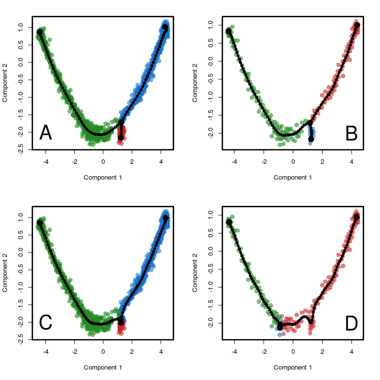

1. MERLoT full (B) MERLoT reduced (C) ElPi full (D) ElPi reduced.

We see that when using the MERLoT hyperparameters the elastic tree follows the topology detected by the scaffold tree. ElPi hyperparameters when using all cells for the elastic tree also capture the overall topology, even though the progenitor branch (red) is truncated. When using the forgiving ElPi hyperparameters with reduced mode the branching location is removed to a high density region, and the progenitor branch is replaced by a bend in the tree.

Before we continue with the successful elastic trees we need to inflate the reduced ones with the full coordinates again:

```r
elastic_reduced <- inflate_elastic_tree(elastic_reduced, CellCoordinates)
```

Now calculate the different embedded trees:

```r
# Embedd the principal elastic tree on the gene expression space from which it was calculated.
elastic_full_merlot = GenesSpaceEmbedding(ExpressionMatrix = Dataset$ExpressionMatrix, ElasticTree = elastic_full)
elastic_reduced_merlot = GenesSpaceEmbedding(ExpressionMatrix = Dataset$ExpressionMatrix, ElasticTree = elastic_reduced)
elastic_full_elpi <- nikoEmbed(ExpressionMatrix = Dataset$ExpressionMatrix, ElasticTree = elastic_full)
elastic_reduced_elpi <- nikoEmbed(ExpressionMatrix = Dataset$ExpressionMatrix, ElasticTree = elastic_reduced)
elpi_full_elpi <- nikoEmbed(ExpressionMatrix = Dataset$ExpressionMatrix, ElasticTree = elpi_full)
elpi_full_merlot <- GenesSpaceEmbedding(ExpressionMatrix = Dataset$ExpressionMatrix, ElasticTree = elpi_full)
```

We calculate the corresponding pseudotimes:

```r
elastic_full_merlot_pt <- CalculatePseudotimes(elastic_full_merlot, T0=3)
elastic_reduced_merlot_pt <- CalculatePseudotimes(elastic_reduced_merlot, T0=3)
elastic_full_elpi_pt <- CalculatePseudotimes(elastic_full_elpi, T0=3)
elastic_reduced_elpi_pt <- CalculatePseudotimes(elastic_reduced_elpi, T0=3)
elpi_full_elpi_pt <- CalculatePseudotimes(elpi_full_elpi, T0=3)
elpi_full_merlot_pt <- CalculatePseudotimes(elpi_full_merlot, T0=3)
```

With the pseudotimes available, we can now plot the expression of genes through pseudotime, allowing a comparison between the different approaches.

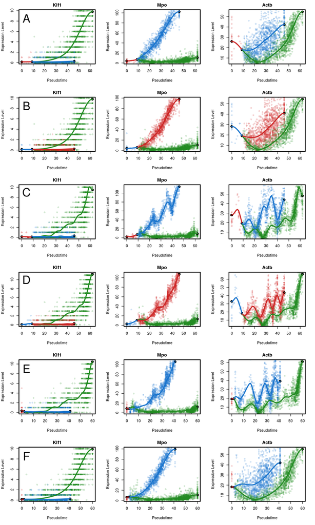

|  | hpms. elastic | reduced mode | hpms. embedded |
| --- | --- | --- | --- |
| (A) | MERLoT | FALSE | MERLoT |
| (B) | MERLoT | TRUE | MERLoT |
| (C) | MERLoT | FALSE | ElPiGraph.R |
| (D) | MERLoT | TRUE | ElPiGraph.R |
| (E) | ElPiGraph.R | FALSE | ElPiGraph.R |
| (F) | ElPiGraph.R | FALSE | MERLoT |